Skip to contents

# Getting Started with rict

Source: [`vignettes/rict.Rmd`](https://github.com/christopherkenny/rict/blob/main/vignettes/rict.Rmd)

```r
library(rict)
```

## Overview

`rict` produces clean, publication-ready tables for redistricting analysis. It is designed to accompany maps from `redist` and related packages, summarizing district-level data on population, demographics, elections, compactness, contiguity, and administrative splits.

The package builds on two core R table libraries:

- [`gt`](https://gt.rstudio.com/) for formatted HTML output
- [`tibble`](https://tibble.tidyverse.org/) for data-frame output (set `as_gt = FALSE`)

## Data

`rict` ships with two example datasets from West Virginia:

- `wv`: a `redist_map` object with county-level demographic, partisan, and geographic data
- `wv_plans`: a `redist_plans` object with sampled redistricting plans and the enacted 2020 congressional plan

```r
data(wv)
data(wv_plans)
```

## Quick start with `rict()`

The simplest entry point is `rict()`, which creates a summary table from a `redist_map` or `redist_plans` object:

```r
rict(wv)
```

| district | pop | pop_white | pop_black | pop_hisp | pop_aian | pop_asian | pop_nhpi | pop_other | pop_two | vap | vap_white | vap_black | vap_hisp | vap_aian | vap_asian | vap_nhpi | vap_other | vap_two | cd_2010 | cd_2020 | pre_20_rep_tru | pre_20_dem_bid | ndv | adv_20 | nrv | arv_20 | sample_1 | sample_2 | sample_3 | … |
| --- | --- | --- | --- | --- | --- | --- | --- | --- | --- | --- | --- | --- | --- | --- | --- | --- | --- | --- | --- | --- | --- | --- | --- | --- | --- | --- | --- | --- | --- | --- |
| 1 | 896067 | 805369 | 36345 | 11331 | 1632 | 6132 | 155 | 2136 | 32967 | 715682 | 649695 | 29039 | 7866 | 1426 | 5030 | 116 | 1294 | 21216 | 73 | 28 | 273523 | 112947 | 112947 | 112947 | 273523 | 273523 | 37 | 31 | 36 | … |
| 2 | 897649 | 793465 | 28404 | 23496 | 1555 | 8771 | 274 | 2516 | 39168 | 717250 | 643345 | 22963 | 15617 | 1335 | 7203 | 217 | 1687 | 24883 | 35 | 54 | 271859 | 123037 | 123037 | 123037 | 271859 | 271859 | 52 | 53 | 50 | … |

For a `redist_plans` object, specify which plan to display:

```r
rict(wv_plans, "cd_2020")
```

| district | total_pop | chain | pop_overlap | total_vap | plan_dev | comp_edge | comp_polsby | pop_white | pop_black | pop_hisp | pop_aian | pop_asian | pop_nhpi | pop_other | pop_two | vap_white | vap_black | vap_hisp | vap_aian | vap_asian | vap_nhpi | vap_other | vap_two | pre_20_rep_tru | pre_20_dem_bid | adv_20 | arv_20 | county_splits | ndv | … |
| --- | --- | --- | --- | --- | --- | --- | --- | --- | --- | --- | --- | --- | --- | --- | --- | --- | --- | --- | --- | --- | --- | --- | --- | --- | --- | --- | --- | --- | --- | --- |
| 1 | 896067 | NA | 1 | 715682 | 0.000881968 | 0.94 | 0.26271 | 805369 | 36345 | 11331 | 1632 | 6132 | 155 | 2136 | 32967 | 649695 | 29039 | 7866 | 1426 | 5030 | 116 | 1294 | 21216 | 273523 | 112947 | 112947 | 273523 | 0 | 112947 | … |
| 2 | 897649 | NA | 1 | 717250 | 0.000881968 | 0.94 | 0.13358 | 793465 | 28404 | 23496 | 1555 | 8771 | 274 | 2516 | 39168 | 643345 | 22963 | 15617 | 1335 | 7203 | 217 | 1687 | 24883 | 271859 | 123037 | 123037 | 271859 | 0 | 123037 | … |

## Specialized tables

For more targeted analysis, use the `rict_*` family of functions. Each accepts a `map` and `plan` argument, and returns either a `gt` table (default) or a tibble.

### Population parity

`rict_population()` shows total population per district and deviation from the ideal (equal) population:

```r
rict_population(map = wv, plan = wv$cd_2020)
```

| District | Population | Deviation People | Deviation % |
| --- | --- | --- | --- |
| 1 | 896,067 | −791 | −0.1% |
| 2 | 897,649 | 791 | 0.1% |

### Demographics

`rict_demographics()` breaks down population and voting-age population (VAP) by race and ethnicity. By default, subcategory columns are normalized to proportions:

```r
rict_demographics(map = wv, plan = wv$cd_2020)
```

| District | Total Population Pop. | Total Population White | Total Population Black | Total Population Hispanic | Total Population Native | Total Population Asian | Total Population NH/PI | Total Population Other | Total Population Two+ | Voting Age Population VAP | Voting Age Population White | Voting Age Population Black | Voting Age Population Hispanic | Voting Age Population Native | Voting Age Population Asian | Voting Age Population NH/PI | Voting Age Population Other | Voting Age Population Two+ |
| --- | --- | --- | --- | --- | --- | --- | --- | --- | --- | --- | --- | --- | --- | --- | --- | --- | --- | --- |
| 1 | 896,067 | 89.9% | 4.1% | 1.3% | 0.2% | 0.7% | 0.0% | 0.2% | 3.7% | 715,682 | 90.8% | 4.1% | 1.1% | 0.2% | 0.7% | 0.0% | 0.2% | 3.0% |
| 2 | 897,649 | 88.4% | 3.2% | 2.6% | 0.2% | 1.0% | 0.0% | 0.3% | 4.4% | 717,250 | 89.7% | 3.2% | 2.2% | 0.2% | 1.0% | 0.0% | 0.2% | 3.5% |

Set `normalize = FALSE` to see raw counts:

```r
rict_demographics(map = wv, plan = wv$cd_2020, normalize = FALSE)
```

| District | Total Population Pop. | Total Population White | Total Population Black | Total Population Hispanic | Total Population Native | Total Population Asian | Total Population NH/PI | Total Population Other | Total Population Two+ | Voting Age Population VAP | Voting Age Population White | Voting Age Population Black | Voting Age Population Hispanic | Voting Age Population Native | Voting Age Population Asian | Voting Age Population NH/PI | Voting Age Population Other | Voting Age Population Two+ |
| --- | --- | --- | --- | --- | --- | --- | --- | --- | --- | --- | --- | --- | --- | --- | --- | --- | --- | --- |
| 1 | 896,067 | 80,536,900.0% | 3,634,500.0% | 1,133,100.0% | 163,200.0% | 613,200.0% | 15,500.0% | 213,600.0% | 3,296,700.0% | 715,682 | 64,969,500.0% | 2,903,900.0% | 786,600.0% | 142,600.0% | 503,000.0% | 11,600.0% | 129,400.0% | 2,121,600.0% |
| 2 | 897,649 | 79,346,500.0% | 2,840,400.0% | 2,349,600.0% | 155,500.0% | 877,100.0% | 27,400.0% | 251,600.0% | 3,916,800.0% | 717,250 | 64,334,500.0% | 2,296,300.0% | 1,561,700.0% | 133,500.0% | 720,300.0% | 21,700.0% | 168,700.0% | 2,488,300.0% |

### Elections

`rict_elections()` summarizes partisan election data. It automatically detects individual contest columns (e.g., `pre_20_dem_bid`), cycle-average columns (`adv_20`, `arv_20`), and normal vote columns (`ndv`, `nrv`), computing Democratic vote share for each:

```r
rict_elections(map = wv, plan = wv$cd_2020)
```

| District | Average Dem. Vote Share Pre-Average | Contests Dem. Vote Share Pres 2020 | Cycle Dem. Vote Share 2020 |
| --- | --- | --- | --- |
| 1 | 29.2% | 29.2% | 29.2% |
| 2 | 31.2% | 31.2% | 31.2% |

### Compactness

`rict_compactness()` computes geometric compactness measures via `redistmetrics`. The default measures are Polsby-Popper, Schwartzberg, Reock, and Convex Hull:

```r
rict_compactness(map = wv, plan = wv$cd_2020)
```

| District | Polsby-Popper | Schwartzberg | Reock | Convex Hull |
| --- | --- | --- | --- | --- |
| 1 | 35.0% | 59.2% | 46.8% | 79.6% |
| 2 | 17.4% | 41.7% | 26.7% | 50.1% |

You can supply custom measures as a named list of functions:

```r
rict_compactness(
  map = wv, plan = wv$cd_2020,
  measures = list(
    "comp_polsby" = redistmetrics::comp_polsby,
    "comp_lw" = redistmetrics::comp_lw
  )
)
```

| District | Polsby-Popper | Length Width |
| --- | --- | --- |
| 1 | 35.0% | 70.0% |
| 2 | 17.4% | 71.8% |

### Contiguity

`rict_contiguity()` checks how many connected pieces each district has:

```r
rict_contiguity(map = wv, plan = wv$cd_2020)
```

| District | Pieces |
| --- | --- |
| 1 | 1 |
| 2 | 1 |

### Administrative splits

`rict_splits()` counts how administrative boundaries (e.g., counties, states) are split across districts:

```r
rict_splits(map = wv, plan = wv$cd_2020, admin = "state")
```

| District | admin_state | total_state | multi_state |
| --- | --- | --- | --- |
| 1 | 1 | 1 | 0 |
| 2 | 1 | 1 | 0 |

### Component populations

`rict_component()` breaks down population by administrative unit within each district:

```r
rict_component(map = wv, plan = wv$cd_2020, admin = "county")
```

| county | pop |
| --- | --- |
| 1 |  |
| 005 | 21,809 |
| 007 | 12,447 |
| 011 | 94,350 |
| 013 | 6,229 |
| 015 | 8,051 |
| 019 | 40,488 |
| 021 | 7,408 |
| 025 | 32,977 |
| 035 | 27,791 |
| 039 | 180,745 |
| 043 | 20,463 |
| 045 | 32,567 |
| 047 | 19,111 |
| 053 | 25,453 |
| 055 | 59,664 |
| 059 | 23,568 |
| 063 | 12,376 |
| 067 | 24,604 |
| 071 | 6,143 |
| 075 | 7,869 |
| 079 | 57,440 |
| 081 | 74,591 |
| 087 | 14,028 |
| 089 | 11,959 |
| 099 | 38,982 |
| 101 | 8,378 |
| 105 | 5,194 |
| 109 | 21,382 |
| 2 |  |
| 001 | 15,465 |
| 003 | 122,076 |
| 009 | 22,559 |
| 017 | 7,808 |
| 023 | 10,976 |
| 027 | 23,093 |
| 029 | 29,095 |
| 031 | 14,299 |
| 033 | 65,921 |
| 037 | 57,701 |
| 041 | 17,033 |
| 049 | 56,205 |
| 051 | 30,591 |
| 057 | 26,938 |
| 061 | 105,822 |
| 065 | 17,063 |
| 069 | 42,425 |
| 073 | 7,653 |
| 077 | 34,216 |
| 083 | 27,932 |
| 085 | 8,444 |
| 091 | 16,705 |
| 093 | 6,762 |
| 095 | 8,313 |
| 097 | 23,816 |
| 103 | 14,442 |
| 107 | 84,296 |

## Getting tibbles instead of gt tables

Every `rict_*` function accepts `as_gt = FALSE` to return a tibble instead of a `gt` table, making it easy to use the results for further computation:

```r
rict_elections(map = wv, plan = wv$cd_2020, as_gt = FALSE)
```

```
#> # A tibble: 2 × 4
#>   District ndshare pre_20 avg_20
#>      <int>   <dbl>  <dbl>  <dbl>
#> 1        1   0.292  0.292  0.292
#> 2        2   0.312  0.312  0.312
```

## Extending gt tables

`rict` provides several helpers for working with `gt` tables:

### Partisan color scales

`data_color_party()` applies a red-to-blue color scale for Democratic vote share columns:

```r
rict(wv_plans, "cd_2020") |>
  data_color_party(columns = "e_dvs")
```

| district | total_pop | chain | pop_overlap | total_vap | plan_dev | comp_edge | comp_polsby | pop_white | pop_black | pop_hisp | pop_aian | pop_asian | pop_nhpi | pop_other | pop_two | vap_white | vap_black | vap_hisp | vap_aian | vap_asian | vap_nhpi | vap_other | vap_two | pre_20_rep_tru | pre_20_dem_bid | adv_20 | arv_20 | county_splits | ndv | … |
| --- | --- | --- | --- | --- | --- | --- | --- | --- | --- | --- | --- | --- | --- | --- | --- | --- | --- | --- | --- | --- | --- | --- | --- | --- | --- | --- | --- | --- | --- | --- |
| 1 | 896067 | NA | 1 | 715682 | 0.000881968 | 0.94 | 0.26271 | 805369 | 36345 | 11331 | 1632 | 6132 | 155 | 2136 | 32967 | 649695 | 29039 | 7866 | 1426 | 5030 | 116 | 1294 | 21216 | 273523 | 112947 | 112947 | 273523 | 0 | 112947 | … |
| 2 | 897649 | NA | 1 | 717250 | 0.000881968 | 0.94 | 0.13358 | 793465 | 28404 | 23496 | 1555 | 8771 | 274 | 2516 | 39168 | 643345 | 22963 | 15617 | 1335 | 7203 | 217 | 1687 | 24883 | 271859 | 123037 | 123037 | 271859 | 0 | 123037 | … |

### Geometry plots

`gt_plot_sf()` embeds small maps of `sf` geometries into a `gt` table:

```r
wv_dist <- wv |> dplyr::group_by(cd_2020) |> dplyr::summarize()
gt::gt(wv_dist) |> gt_plot_sf()
```

cd_2020

geom

1

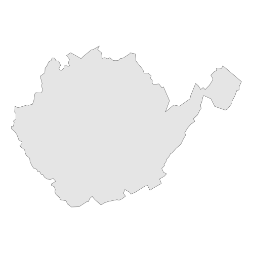

2

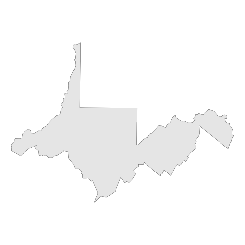

### Compactness plots

`gt_plot_compactness()` adds visual compactness overlays (e.g., equal-area circles, convex hulls) to a table of compactness metrics:

```r
rict(wv_plans, "cd_2020") |>
  gt_plot_compactness(wv, wv$cd_2020)
```

district

total_pop

chain

pop_overlap

total_vap

plan_dev

comp_edge

comp_polsby

pop_white

pop_black

pop_hisp

pop_aian

pop_asian

pop_nhpi

pop_other

pop_two

vap_white

vap_black

vap_hisp

vap_aian

vap_asian

vap_nhpi

vap_other

vap_two

pre_20_rep_tru

pre_20_dem_bid

adv_20

arv_20

county_splits

ndv

nrv

ndshare

e_dvs

pr_dem

e_dem

pbias

egap

gg_polsby

1

896067

NA

1

715682

0.000881968

0.94

0.26271

805369

36345

11331

1632

6132

155

2136

32967

649695

29039

7866

1426

5030

116

1294

21216

273523

112947

112947

273523

0

112947

273523

0.2923

0.2923

0

0

0

0.104

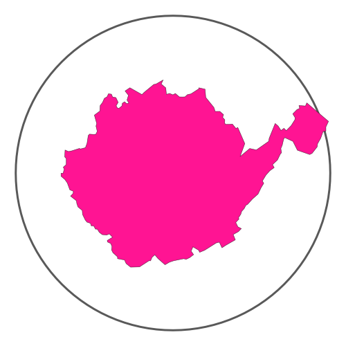

2

897649

NA

1

717250

0.000881968

0.94

0.13358

793465

28404

23496

1555

8771

274

2516

39168

643345

22963

15617

1335

7203

217

1687

24883

271859

123037

123037

271859

0

123037

271859

0.3116

0.3116

0

0

0

0.104

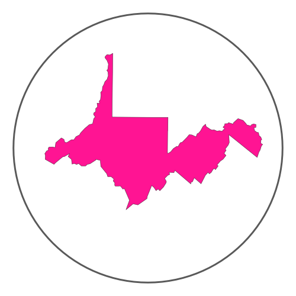

### Other gt utilities

- `gt_get_data()`: extract the underlying tibble from a `gt` table
- `gt_hide_lists()`: hide list-columns (e.g., adjacency lists) from display

```r
tab <- rict(wv)
gt_get_data(tab)
```

```
#> # A tibble: 2 × 40
#>   district    pop pop_white pop_black pop_hisp pop_aian pop_asian pop_nhpi
#>      <int>  <dbl>     <dbl>     <dbl>    <dbl>    <dbl>     <dbl>    <dbl>
#> 1        1 896067    805369     36345    11331     1632      6132      155
#> 2        2 897649    793465     28404    23496     1555      8771      274
#> # ℹ 32 more variables: pop_other <dbl>, pop_two <dbl>, vap <dbl>,
#> #   vap_white <dbl>, vap_black <dbl>, vap_hisp <dbl>, vap_aian <dbl>,
#> #   vap_asian <dbl>, vap_nhpi <dbl>, vap_other <dbl>, vap_two <dbl>,
#> #   cd_2010 <int>, cd_2020 <int>, pre_20_rep_tru <dbl>, pre_20_dem_bid <dbl>,
#> #   ndv <dbl>, adv_20 <dbl>, nrv <dbl>, arv_20 <dbl>, sample_1 <int>,
#> #   sample_2 <int>, sample_3 <int>, sample_4 <int>, sample_5 <int>,
#> #   sample_6 <int>, sample_7 <int>, sample_8 <int>, sample_9 <int>, …
```